# Generating a random number sequence and finding the probabilities of containing a given number

Evgeni Ovcharov

July 30, 2017

## Problem

Consider a random number sequence $S_n$ generated by the relation
$$S_{n+1} = S_n + x, \quad S_0 = 0, \quad n = 0,1, \dots,$$
where $x$ is drawn at random and with equal probability from a given set of numbers $O = \{n_1, n_2, ..., n_m\}$. Given a threshold value $L$, let $S_l$ be the first member of the sequence such that $S_l \geq L$. Using Monte Carlo simulations compute the probability of each randomly generated value $S_l$. Notice also that $\operatorname{P}(S_l = L)$ is in fact the probability of the random sequnce $S_n$ to contain an arbitrarily given number $L$.

## Solution with R code

The following are the main parameters of the solution given with some example values.

```r
L = 100
sample_space = c(1,3,5)
N_trials = 200
N_est = 100
```

The function draws $N$ numbers from a sample space, here identified with the set $O$.

```r
draws = function(N, sample_space){
  sample(sample_space, size = N, replace = TRUE, prob = rep(1/length(sample_space), length(sample_space)))
}
```

The function constructs the sequence $S_n$ until it reaches or exceeds the threshold $L$ and returns its last value.

```r
last_value = function(L, sample_space){
  # this parts speeds up the computation of S
  S = sum(draws(floor(L/ (1.1*mean(sample_space))), sample_space))
  #usually, S << L, but in some rare cases where S >= L we need to backtrack
  while(S>=L){
    S = S - draws(1, sample_space)
  }
  #assuming S < L, we increment S until it reaches the end condition
  while(S<L){
    S = S + draws(1, sample_space)
  }
  return(S)
}
```

The function computes the relative frequencies of the outcomes $S_l$ out of $N_{trials}$ trials.

```r
freq = function(L, sample_space, N_trials){
  t = replicate(N_trials, last_value(L, sample_space))
  data = table(t)/length(t)
}
```

We repeat the estimation of the relative frequences $N_{est}$ times and then take the mean value to increase accuracy.

```r
list_rel_freq = replicate(N_est, freq(L, sample_space, N_trials))
mean_rel_freq = signif(sapply(as.list(data.frame(t(list_rel_freq))), mean), digits = 2)
```

Playing with different sets $O$, one may empirically discover the relation
$$\operatorname{P}(S_l = L) \rightarrow 1/ \operatorname{E}X, \quad \text{as } L\rightarrow\infty,$$
where $X$ is the random variable generating $S_n$. In conclusion, we display the results for our example values.

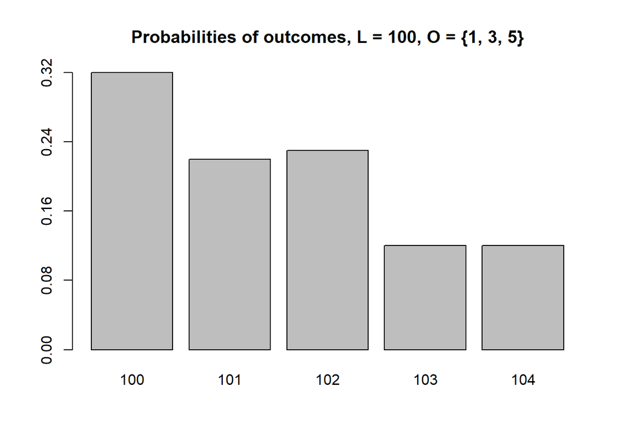

```r
barplot(mean_rel_freq, yaxp=c(0, max(mean_rel_freq), length(sample_space)+1), names.arg = L:(L+length(mean_rel_freq)-1), main = paste0("Probabilities of outcomes, L = ", L, ", ", "O = ", "{", toString(sample_space), "}"))
```